# Multiple linear regression

## Grading the professor

Many college courses conclude by giving students the opportunity to evaluate the course and the instructor anonymously. However, the use of these student evaluations as an indicator of course quality and teaching effectiveness is often criticized because these measures may reflect the influence of non-teaching related characteristics, such as the physical appearance of the instructor. The article titled, “Beauty in the classroom: instructors’ pulchritude and putative pedagogical productivity” (Hamermesh and Parker, 2005) found that instructors who are viewed to be better looking receive higher instructional ratings. (Daniel S. Hamermesh, Amy Parker, Beauty in the classroom: instructors pulchritude and putative pedagogical productivity, *Economics of Education Review*, Volume 24, Issue 4, August 2005, Pages 369-376, ISSN 0272-7757, 10.1016/j.econedurev.2004.07.013. http://www.sciencedirect.com/science/article/pii/S0272775704001165.)

In this lab we will analyze the data from this study in order to learn what goes into a positive professor evaluation.

## The data

The data were gathered from end of semester student evaluations for a large sample of professors from the University of Texas at Austin. In addition, six students rated the professors’ physical appearance. (This is aslightly modified version of the original data set that was released as part of the replication data for *Data Analysis Using Regression and Multilevel/Hierarchical Models* (Gelman and Hill, 2007).) The result is a data frame where each row contains a different course and columns represent variables about the courses and professors.

```r
load("more/evals.RData")
```

| variable | description |
| --- | --- |
| `score` | average professor evaluation score: (1) very unsatisfactory - (5) excellent. |
| `rank` | rank of professor: teaching, tenure track, tenured. |
| `ethnicity` | ethnicity of professor: not minority, minority. |
| `gender` | gender of professor: female, male. |
| `language` | language of school where professor received education: english or non-english. |
| `age` | age of professor. |
| `cls_perc_eval` | percent of students in class who completed evaluation. |
| `cls_did_eval` | number of students in class who completed evaluation. |
| `cls_students` | total number of students in class. |
| `cls_level` | class level: lower, upper. |
| `cls_profs` | number of professors teaching sections in course in sample: single, multiple. |
| `cls_credits` | number of credits of class: one credit (lab, PE, etc.), multi credit. |
| `bty_f1lower` | beauty rating of professor from lower level female: (1) lowest - (10) highest. |
| `bty_f1upper` | beauty rating of professor from upper level female: (1) lowest - (10) highest. |
| `bty_f2upper` | beauty rating of professor from second upper level female: (1) lowest - (10) highest. |
| `bty_m1lower` | beauty rating of professor from lower level male: (1) lowest - (10) highest. |
| `bty_m1upper` | beauty rating of professor from upper level male: (1) lowest - (10) highest. |
| `bty_m2upper` | beauty rating of professor from second upper level male: (1) lowest - (10) highest. |
| `bty_avg` | average beauty rating of professor. |
| `pic_outfit` | outfit of professor in picture: not formal, formal. |
| `pic_color` | color of professor’s picture: color, black & white. |

## Exploring the data

1. Is this an observational study or an experiment? The original research question posed in the paper is whether beauty leads directly to the differences in course evaluations. Given the study design, is it possible to answer this question as it is phrased? If not, rephrase the question.

*A: Research is an observational study. I believe original research question draws students focus on to the word `beauty`. It also sounds more appealing, and students may want to answer the question more directly. Given a chance to rephrase I would ask students what factors contributed to staying focused on the course, instructors physical appearance, teaching style or course content?*

2. Describe the distribution of `score`. Is the distribution skewed? What does that tell you about how students rate courses? Is this what you expected to see? Why, or why not?

*A: Looing at the summary of `score`, most students rated instructors very highly. That indicates course content and teaching style was important than the physical appearance of the instructors. However, the histogram shows data is left skewed, and there are some outliers. In other words, there were some students to whom instructors physical appearance mattered more than course content and teaching style. I did expect some skewness in the data. A small portion of the students giving remarkably lower or higher rating would skew the data.*

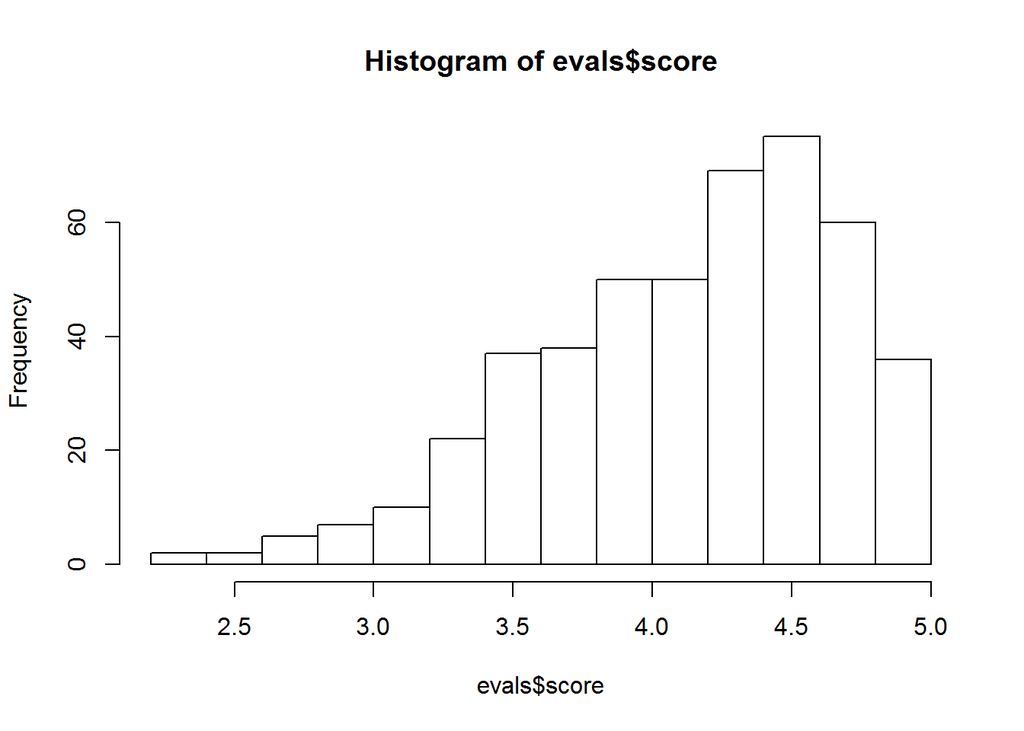

```r
hist(evals$score)
```

```r
summary(evals$score)
```

```
##    Min. 1st Qu.  Median    Mean 3rd Qu.    Max.
##   2.300   3.800   4.300   4.175   4.600   5.000
```

3. Excluding `score`, select two other variables and describe their relationship using an appropriate visualization (scatterplot, side-by-side boxplots, or mosaic plot).

*A: Box plot shows gender had no impact while rating instructors physical appearance. Both male and female instructors received similar rating.*

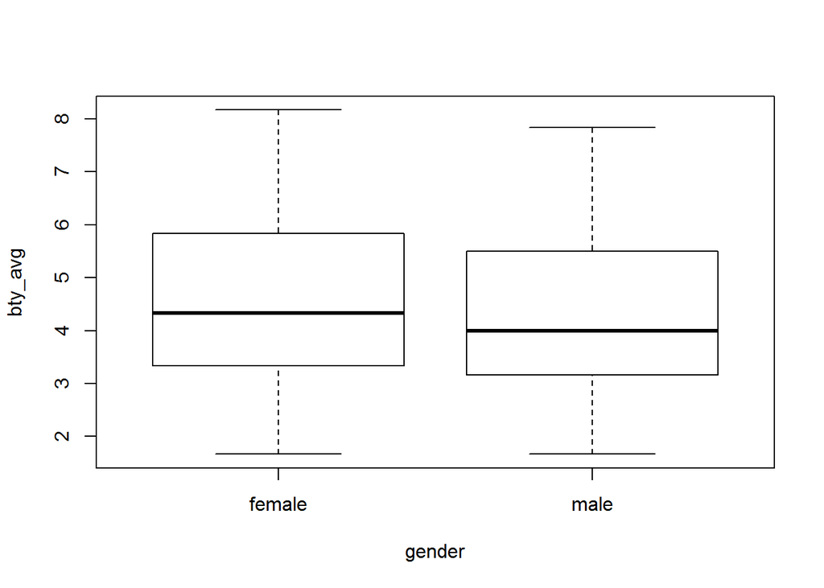

```r
plot(bty_avg ~ gender, data=evals)
```